# Cyclistic Bike-Share Usage Analysis

Joseph Brighter

2025-11-24

# Executive Summary

Cyclistic, Chicago’s public bike-share program, aims to increase annual memberships, which generate more predictable and profitable revenue than one-off casual rides. To support this goal, I analyzed trip data from Q1 2019 and Q1 2020 to understand how casual riders and annual members use the system differently. The goal was to identify behavioral patterns that could inform targeted marketing strategies for converting casual users into members.

The analysis reveals a clear divide between the two types of riders. Members account for over ten times more trips than casual riders, and their usage is highly consistent across weekdays, strongly suggesting regular commuting behavior. In contrast, casual riders take significantly fewer rides, but their trips last nearly three times longer. Casual usage peaks on weekends, aligning with recreational outings, tourism, and leisure-based travel. Casual riders also show noticeable spikes in trip duration on Wednesdays and weekends, indicating flexible, non-commute-driven patterns.

These insights show that casual riders are not opposed to cycling—they simply use the service differently and are motivated by different needs. Their behaviors reveal a major opportunity: Cyclistic can convert a portion of these leisure-oriented riders into paying members by offering membership options and incentives that align with how they already ride.

1. A weekend-focused or leisure-oriented membership tier,
2. In-app price comparison prompts showing casual riders how a membership would reduce their long-ride costs.
3. Digital marketing campaigns activated around high-casual-usage times and locations, and

Together, these approaches align directly with observed behaviors and have strong potential to convert casual users into annual members while preserving the value members already receive.

# 1. Business Task

Cyclistic’s marketing team seeks to understand **how annual members and casual riders use the bike-share system differently**, in order to design strategies that convert more casual riders into members.

I am seeking to understand these differences and come up with recommendations based on that data provided.

# 2. Data Sources

This analysis uses the following datasets:

- **Divvy_Trips_2019_Q1.csv**
- **Divvy_Trips_2020_Q1.csv**

Both datasets were provided by *Lyft Bikes and Scooters, LLC* (operating the Divvy system for the City of Chicago) and are licensed under the Divvy **Data License Agreement**, which allows analysis and distribution as part of non-commercial reports and studies.

**Key Fields Used:**

- Trip ID
- Start and end timestamps
- Start and end station names and IDs
- Rider type (`member` or `casual`)

**Limitations:**

- Only Q1 of each year is included
- No demographic data
- No personal user data
- Possible anomalies from early COVID-19 impacts in 2020

# 3. Data Cleaning & Preparation

All data cleaning and processing were performed in a separate R script for clarity and reproducibility:

**Full script:**

https://github.com/jbrighter98/Cyclistic-Data-Analysis/blob/main/scripts/data_cleaning.R

This report only highlights the *key* transformations used to prepare the data for analysis.

## 3.2 Example: Raw Data Snapshot

```r
glimpse(trips_2019_raw)
```

```
## Rows: 365,069
## Columns: 12
## $ trip_id           <int> 22178528, 22178527, 22178526, 22178525, 22178524, 22…
## $ start_time        <chr> "2019-03-31 23:53:48", "2019-03-31 23:53:08", "2019-…
## $ end_time          <chr> "2019-04-01 0:01:16", "2019-03-31 23:56:06", "2019-0…
## $ bikeid            <int> 5589, 4384, 3584, 3270, 1501, 3873, 4814, 667, 4304,…
## $ tripduration      <chr> "448", "178", "846", "332", "757", "270", "113", "23…
## $ from_station_id   <int> 248, 321, 283, 129, 38, 69, 198, 199, 181, 210, 181,…
## $ from_station_name <chr> "Woodlawn Ave & 55th St", "Wabash Ave & 9th St", "La…
## $ to_station_id     <int> 247, 39, 273, 202, 29, 183, 233, 26, 24, 210, 24, 21…
## $ to_station_name   <chr> "Shore Dr & 55th St", "Wabash Ave & Adams St", "Mich…
## $ usertype          <chr> "Subscriber", "Subscriber", "Subscriber", "Subscribe…
## $ gender            <chr> "Male", "Male", "Male", "Male", "Male", "Male", "Mal…
## $ birthyear         <int> 1998, 1969, 1984, 1992, 1993, 1985, 1971, 1984, NA, …
```

```r
glimpse(trips_2020_raw)
```

```
## Rows: 426,887
## Columns: 13
## $ ride_id            <chr> "EACB19130B0CDA4A", "8FED874C809DC021", "789F3C21E4…
## $ rideable_type      <chr> "docked_bike", "docked_bike", "docked_bike", "docke…
## $ started_at         <chr> "2020-01-21 20:06:59", "2020-01-30 14:22:39", "2020…
## $ ended_at           <chr> "2020-01-21 20:14:30", "2020-01-30 14:26:22", "2020…
## $ start_station_name <chr> "Western Ave & Leland Ave", "Clark St & Montrose Av…
## $ start_station_id   <int> 239, 234, 296, 51, 66, 212, 96, 96, 212, 38, 117, 1…
## $ end_station_name   <chr> "Clark St & Leland Ave", "Southport Ave & Irving Pa…
## $ end_station_id     <int> 326, 318, 117, 24, 212, 96, 212, 212, 96, 100, 632,…
## $ start_lat          <dbl> 41.9665, 41.9616, 41.9401, 41.8846, 41.8856, 41.889…
## $ start_lng          <dbl> -87.6884, -87.6660, -87.6455, -87.6319, -87.6418, -…
## $ end_lat            <dbl> 41.9671, 41.9542, 41.9402, 41.8918, 41.8899, 41.884…
## $ end_lng            <dbl> -87.6674, -87.6644, -87.6530, -87.6206, -87.6343, -…
## $ member_casual      <chr> "member", "member", "member", "member", "member", "…
```

## 3.3 Example: Key Transformations

```r
# Example: Adding columns of standardized names
trips_2020_working <- trips_2020_working %>%
  mutate(
    start_time = as_datetime(started_at, format="%Y-%m-%d %H:%M:%S"),
    end_time = as_datetime(ended_at, format="%Y-%m-%d %H:%M:%S"),
    usertype = member_casual
  )

# Example: Adding new columns ride_duration and day_of_the_week
trips_2020_working <- trips_2020_working %>%
  mutate(
    ride_length = difftime(end_time, start_time, units="secs"),
    day_of_week = weekdays(start_time)
  )

# Example: Selecting common useful columns
trips_2020_cleaned <- trips_2020_working %>%
  select(
    ride_id,
    start_time,
    end_time,
    start_station_name,
    start_station_id,
    end_station_name,
    end_station_id,
    usertype,
    ride_length,
    day_of_week
  )

# Example: Combining 2019 and 2020
all_trips_cleaned <- bind_rows(trips_2019_cleaned, trips_2020_cleaned)
```

## 3.4 Cleaned Dataset Preview

```r
head(all_trips_cleaned)
```

```
##    ride_id          start_time            end_time        start_station_name
## 1 22178528 2019-03-31 23:53:48 2019-04-01 00:01:16    Woodlawn Ave & 55th St
## 2 22178527 2019-03-31 23:53:08 2019-03-31 23:56:06       Wabash Ave & 9th St
## 3 22178526 2019-03-31 23:52:38 2019-04-01 00:06:44 LaSalle St & Jackson Blvd
## 4 22178525 2019-03-31 23:52:37 2019-03-31 23:58:09 Blue Island Ave & 18th St
## 5 22178524 2019-03-31 23:51:32 2019-04-01 00:04:09        Clark St & Lake St
## 6 22178522 2019-03-31 23:47:05 2019-03-31 23:51:35    Damen Ave & Pierce Ave
##   start_station_id                     end_station_name end_station_id usertype
## 1              248                   Shore Dr & 55th St            247   member
## 2              321                Wabash Ave & Adams St             39   member
## 3              283               Michigan Ave & 18th St            273   member
## 4              129                 Halsted St & 18th St            202   member
## 5               38             Noble St & Milwaukee Ave             29   member
## 6               69 Damen Ave & Thomas St (Augusta Blvd)            183   member
##   ride_length day_of_week
## 1    448 secs      Sunday
## 2    178 secs      Sunday
## 3    846 secs      Sunday
## 4    332 secs      Sunday
## 5    757 secs      Sunday
## 6    270 secs      Sunday
```

# 4. Analysis

This section explores how members an casual riders differ in their patterns

## 4.1 Ride Volume Comparison

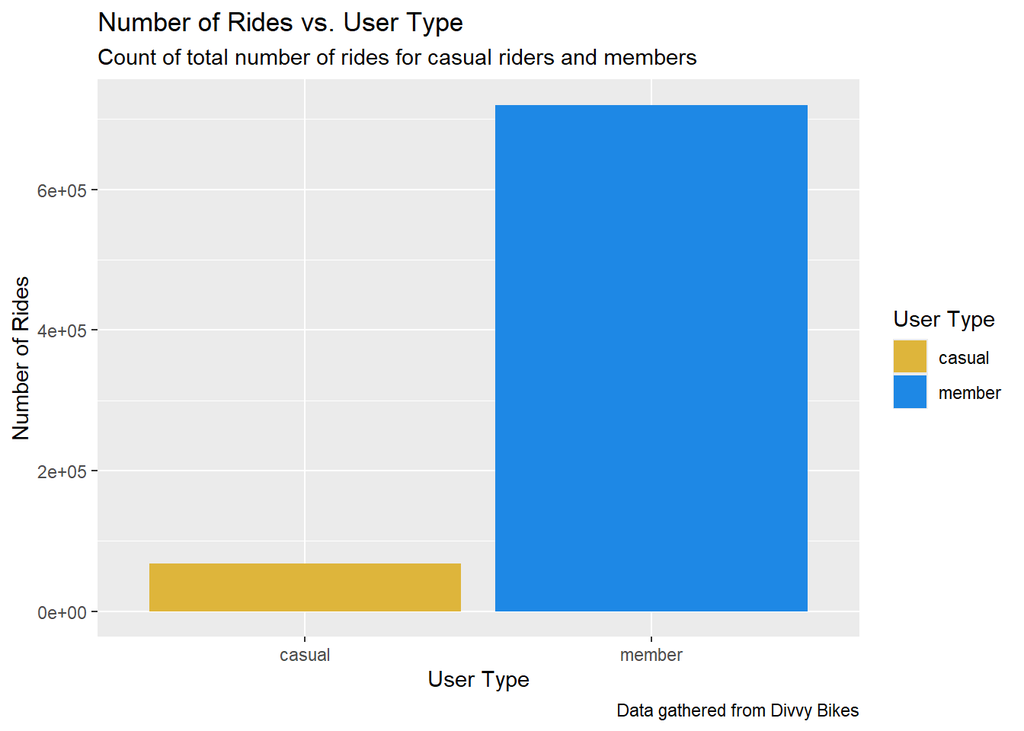

Members make up over 10x more of the total amount of rides than casual riders.

## 4.2 Ride Duration Comparison

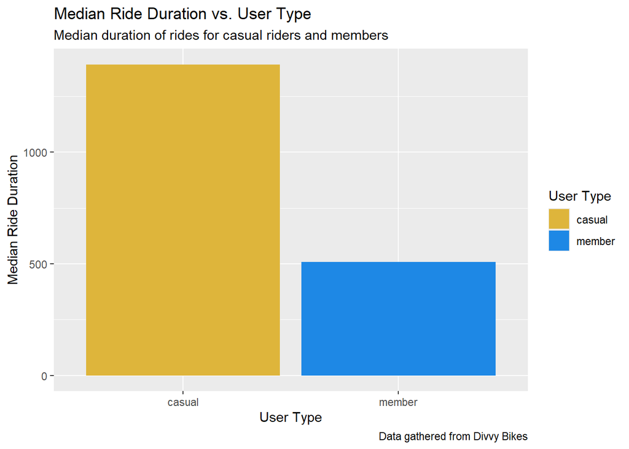

Casual users, on average, ride 2.5x longer than members.

## 4.3 Weekly Usage Trends

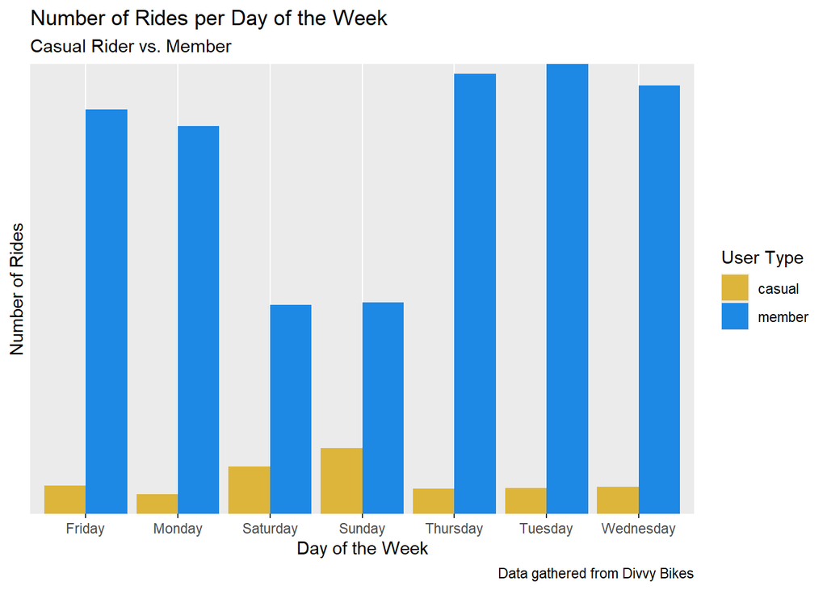

Members make up the significant chunk of rides with higher volume Monday through Friday than the weekends, likely due to daily commuters. Casual riders have a larger volume on the weekends, likely due to leisure and tourism.

## 4.4 Ride Duration by Day of Week

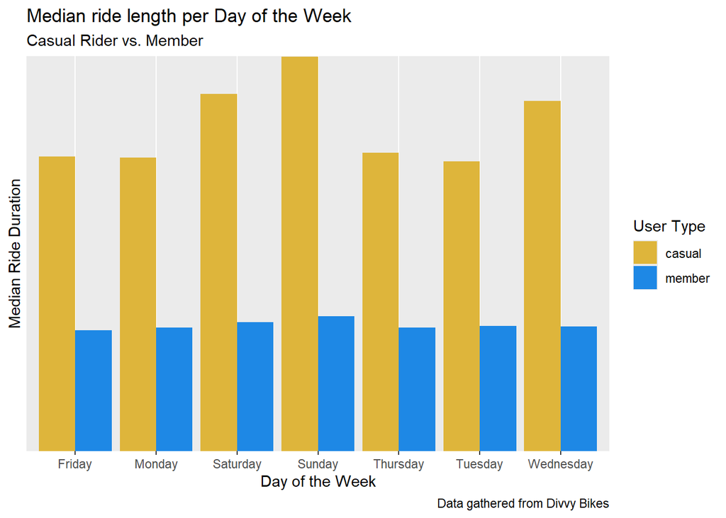

Members have typically, on average, consistent ride lengths throughout the week. Casual riders seem to have longer rides on weekends and Wednesdays. This is consistent with leisure and sight-seeing tourism.

# 5. Key Findings

- Members take **~10x more rides** than casual users.
- Casual riders take **2.5x longer rides**.
- Members ride mostly during **weekdays** (likely commuting).
- Casual riders ride more on **weekends** (likely leisure/tourism).
- Casual rider trip duration spike on **Wednesdays and weekends**.

# 6. Recommendations

Based on the findings above, Cyclistic can take the following actions to convert casual riders into members:

### Recommendation 1 - Create a Weekend-Only or Leisure Tier Membership

If casual members repeatedly use the bikes for leisure, offering a bike membership that has more restrictions, but at a lower price, may attract those users instead of them paying for the full membership. This plan converts a large chunk of casual riders who are price-sensitive but consistent in their leisure behavior.

### Recommendation 2 - Introduce Cost-Saving Prompts for Casual Riders taking long trips

After a casual rider takes a long trip, or rides a suffiencent amount of time in a month, we could send the user a message on the app saying something along the lines of

“You could have saved X% with a membership” or “You could have saved $X with a membership”

This message showing the amount of money they could have saved along with a prompt to sign up will encourage conversion.

### Recommendation 3 - Target Weekend Casual Riders with Well-Placed Digital Ads

Since casual ridership spikes on weekends, we would know exactly when or where they are riding. We could serve the ads in tourist hotspots and popular event areas on Friday afternoons, Saturdays and Sundays. This increases visibility at the moment users are most likely to convert.

# Limitations on Data and Analysis

The following are some limitations on the data and the ability to use it to do analysis:

- The datasets only cover Q1 of both 2019 and 2020. We are missing data for the other quarters which could influence findings and recommendations
- The data does not include any personal information about the users. It could be the case that there are very few repeat casual riders, which would influence recommendations.
- Q1 of 2020 included the beginning of the 2020 pandemic, influencing user behavior at the end of the quarter. User behavior could also be different today after the pandemic.

# Appendix

#### A: Full cleaning Script

https://github.com/jbrighter98/Cyclistic-Data-Analysis/blob/main/scripts/data_cleaning.R

#### B: Full Analysis Script

https://github.com/jbrighter98/Cyclistic-Data-Analysis/blob/main/scripts/data_analysis.R

#### C: Raw Data

https://github.com/jbrighter98/Cyclistic-Data-Analysis/tree/main/data_raw

This project comes from Google Data Analyst Certificate on Coursera.org

Cyclistic is not a real company and the data is purposefully not complete to protect user information.